# Human Activity Recognition - Classification prediction

Sateesh

March 9, 2017

## Summary

### Data preparation and exploratory analysis.

```r
library(caret)
library(tree)
library(gbm)
library(ggplot2)
library(randomForest)
library(plyr)
library(MASS)
```

We will be loading training and test data in order to perform our analysis. The test data don’t have the ‘classe’ feature which we will be predicting based on machine learning algorithm. Before we run our initial analysis, select features with roll,pitch,yaw,total,gyros,accel,magnet for all the sensors.

```r
 ## data download

urlt<-"https://d396qusza40orc.cloudfront.net/predmachlearn/pml-training.csv"
download.file(url=urlt,destfile='pml-training.csv')
training<-read.csv("pml-training.csv",stringsAsFactors = F,na.strings=c("#DIV/0!",'',"NA"))  ## convert factors into numbers

urlts<-"https://d396qusza40orc.cloudfront.net/predmachlearn/pml-testing.csv"
download.file(url=urlts,destfile='pml-testing.csv')
testing<-read.csv("pml-testing.csv",stringsAsFactors = F,na.strings=c("#DIV/0!",'','NA'))

set.seed(330)
wle.data<-training[,grep("^roll|^pitch|^yaw|^total|^gyros|^accel|^magnet|^classe",names(training))]
wle.data$classe<-as.factor(wle.data$classe)
str(wle.data)
```

```
## 'data.frame':    19622 obs. of  53 variables:
##  $ roll_belt           : num  1.41 1.41 1.42 1.48 1.48 1.45 1.42 1.42 1.43 1.45 ...
##  $ pitch_belt          : num  8.07 8.07 8.07 8.05 8.07 8.06 8.09 8.13 8.16 8.17 ...
##  $ yaw_belt            : num  -94.4 -94.4 -94.4 -94.4 -94.4 -94.4 -94.4 -94.4 -94.4 -94.4 ...
##  $ total_accel_belt    : int  3 3 3 3 3 3 3 3 3 3 ...
##  $ gyros_belt_x        : num  0 0.02 0 0.02 0.02 0.02 0.02 0.02 0.02 0.03 ...
##  $ gyros_belt_y        : num  0 0 0 0 0.02 0 0 0 0 0 ...
##  $ gyros_belt_z        : num  -0.02 -0.02 -0.02 -0.03 -0.02 -0.02 -0.02 -0.02 -0.02 0 ...
##  $ accel_belt_x        : int  -21 -22 -20 -22 -21 -21 -22 -22 -20 -21 ...
##  $ accel_belt_y        : int  4 4 5 3 2 4 3 4 2 4 ...
##  $ accel_belt_z        : int  22 22 23 21 24 21 21 21 24 22 ...
##  $ magnet_belt_x       : int  -3 -7 -2 -6 -6 0 -4 -2 1 -3 ...
##  $ magnet_belt_y       : int  599 608 600 604 600 603 599 603 602 609 ...
##  $ magnet_belt_z       : int  -313 -311 -305 -310 -302 -312 -311 -313 -312 -308 ...
##  $ roll_arm            : num  -128 -128 -128 -128 -128 -128 -128 -128 -128 -128 ...
```

[output cut: 39 more lines]

### Fitting randomforest model

We’ll first fit multiclassification tree model using randomforest. We use model formula classe~. with ntree=50 to find the most important factors which describes the most variance in the data. (we can also use pca to reduce the dimension). By default, randomforest will use leave-one-out cross validation test via out-of-bag (OOB) testing.

```r
##  find important columns using rf
trainIndex<-createDataPartition(wle.data$classe,p=.7,list=F)
rffit<-randomForest(classe~.,data=wle.data[trainIndex,],importance=T,prox=T, ntree=50)
print(rffit)
```

```
##
## Call:
##  randomForest(formula = classe ~ ., data = wle.data[trainIndex,      ], importance = T, prox = T, ntree = 50)
##                Type of random forest: classification
##                      Number of trees: 50
## No. of variables tried at each split: 7
##
##         OOB estimate of  error rate: 0.87%
## Confusion matrix:
##      A    B    C    D    E class.error
## A 3898    5    0    1    2 0.002048131
## B   24 2617   16    0    1 0.015425132
## C    0   24 2364    8    0 0.013355593
## D    0    1   27 2222    2 0.013321492
## E    0    0    2    6 2517 0.003168317
```

Plot the important factors that contribute most to the variance.

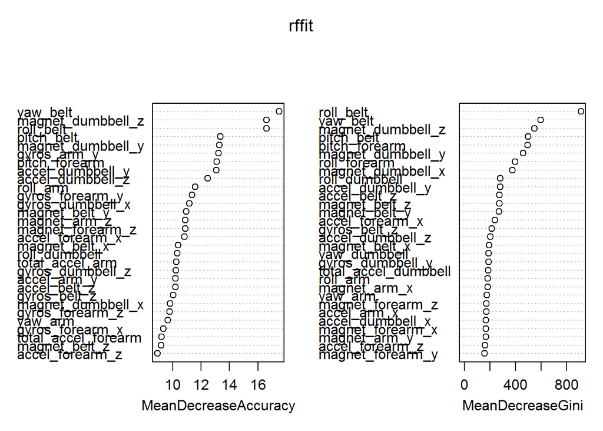

```r
varImpPlot(rffit)
```

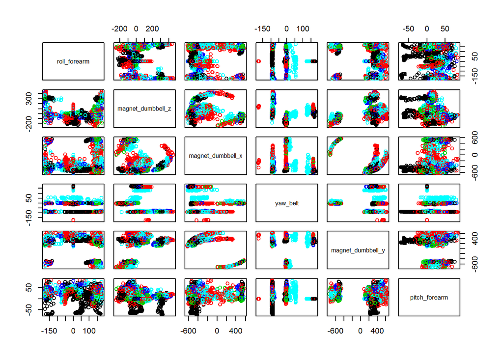

```r
imp<-as.data.frame(sort(rffit$importance[,1],decreasing = T))
welcols<-as.vector(rownames(imp)[1:34])
wle.data.imp<-subset(wle.data,select=c(welcols,"classe"))
smp<-sample(1:nrow(wle.data.imp),2000)
plot(wle.data.imp[smp,welcols[1:6]],col=wle.data.imp[smp,]$classe)
```

### Final randomforst fit with important factors.

Now, lets plot the final randomforest model by including the important factors. We will use ntree=200 to improve OOB error which is our cross validation. Train the model on 70% of the data and verify the error rate/accuracy on 30% before we finally use the model to test against the 20 test samples.

```r
# train the model with training set
rffit<-randomForest(classe~.,data=wle.data.imp[trainIndex,],importance=T,prox=T, ntree=200,do.trace=50)
```

```
## ntree      OOB      1      2      3      4      5
##    50:   1.00%  0.26%  1.58%  1.63%  1.51%  0.48%
##   100:   0.77%  0.20%  1.17%  1.21%  1.15%  0.48%
##   150:   0.70%  0.18%  1.05%  1.21%  0.98%  0.40%
##   200:   0.64%  0.13%  0.98%  1.04%  0.89%  0.48%
```

```r
print(rffit)
```

```
##
## Call:
##  randomForest(formula = classe ~ ., data = wle.data.imp[trainIndex,      ], importance = T, prox = T, ntree = 200, do.trace = 50)
##                Type of random forest: classification
##                      Number of trees: 200
## No. of variables tried at each split: 5
##
##         OOB estimate of  error rate: 0.64%
## Confusion matrix:
##      A    B    C    D    E class.error
## A 3901    3    1    0    1 0.001280082
## B   12 2632   14    0    0 0.009781791
## C    0   19 2371    6    0 0.010434057
## D    0    0   19 2232    1 0.008880995
## E    0    0    5    7 2513 0.004752475
```

```r
## predict/fit using test set.
rfpred<-predict(rffit,newdata = wle.data.imp[-trainIndex,])
tbl<-confusionMatrix(wle.data.imp[-trainIndex,]$classe,rfpred)$table

conftbl<-function(tab) {
  conCV1 <- rbind(tab[1, ]/sum(tab[1, ]), tab[2, ]/sum(tab[2, ]),
                  tab[3, ]/sum(tab[3, ]),tab[4, ]/sum(tab[4, ]),
                  tab[5, ]/sum(tab[5, ]))

  dimnames(conCV1) <- list(Actual = c("A", "B","C","D","E"), "Predicted" = c("A","B","C","D","E"))
  print(round(conCV1, 3))
}
tbl
```

```
##           Reference
## Prediction    A    B    C    D    E
##          A 1672    1    0    1    0
##          B    5 1133    1    0    0
##          C    0    5 1020    1    0
##          D    0    0    6  958    0
##          E    0    0    1    3 1078
```

```r
conftbl(tbl)
```

```
##       Predicted
## Actual     A     B     C     D     E
##      A 0.999 0.001 0.000 0.001 0.000
##      B 0.004 0.995 0.001 0.000 0.000
##      C 0.000 0.005 0.994 0.001 0.000
##      D 0.000 0.000 0.006 0.994 0.000
##      E 0.000 0.000 0.001 0.003 0.996
```

```r
accuracy<-mean(rfpred==wle.data.imp[-trainIndex,]$classe)
```

The model accuracy rate is 0.9959218

### Testing with test data

Using the final random forest model, now we’ll test the 20 test samples to predict the activities/classe.

```r
## test the fit
test.data<-testing[,grep("^roll|^pitch|^yaw|^total|^gyros|^accel|^magnet|^classe",names(testing))]
test.data.imp<-subset(test.data,select=c(welcols))
rftestpred<-predict(rffit,newdata = test.data.imp)
rftestpred
```

```
##  1  2  3  4  5  6  7  8  9 10 11 12 13 14 15 16 17 18 19 20
##  B  A  B  A  A  E  D  B  A  A  B  C  B  A  E  E  A  B  B  B
## Levels: A B C D E
```

## Conclusion

The random forest model correctly identifies the activity based on the features form the sensor data with almost 0.9959218 accuracy.

## Appendix.

Quadratic linear discriminant analysis will also provide accurate prediction. Here is the R code to fit the model and predict the test data.

```r
###  qda fit
qdafit.cv<-qda(classe~.,wle.data.imp,CV=TRUE)
tab<-table(wle.data.imp$classe,qdafit.cv$class)
cm<-confusionMatrix(wle.data.imp$classe,qdafit.cv$class)
cm$table
```

```
##           Reference
## Prediction    A    B    C    D    E
##          A 5143  134  140  132   30
##          B  331 2956  466   16   27
##          C   12  166 3200   27   17
##          D    8   23  575 2557   53
##          E   12  169  159   84 3183
```

```r
conftbl(cm$table)
```

```
##       Predicted
## Actual     A     B     C     D     E
##      A 0.922 0.024 0.025 0.024 0.005
##      B 0.087 0.779 0.123 0.004 0.007
##      C 0.004 0.049 0.935 0.008 0.005
##      D 0.002 0.007 0.179 0.795 0.016
##      E 0.003 0.047 0.044 0.023 0.882
```

```r
# WITHOUT CV
qdafit<-qda(classe~.,data=wle.data.imp[trainIndex,])
har.qda.values <- predict(qdafit)

# test with hold hout data.
qdapred<-predict(qdafit,wle.data.imp[-trainIndex,])
tbl<-confusionMatrix(wle.data.imp[-trainIndex,]$classe,qdapred$class)$table
mean(wle.data.imp[-trainIndex,]$classe==qdapred$class)
```

```
## [1] 0.8657604
```

```r
conftbl(tbl)
```

```
##       Predicted
## Actual     A     B     C     D     E
##      A 0.927 0.021 0.021 0.022 0.010
##      B 0.102 0.763 0.123 0.006 0.006
##      C 0.006 0.055 0.924 0.005 0.011
##      D 0.005 0.005 0.155 0.814 0.021
##      E 0.003 0.052 0.043 0.032 0.870
```

```r
## test dataset
qdatestpred<-predict(qdafit,newdata = test.data)
qdatestpred$class
```

```
##  [1] A A B A A E D D A A B C B A E E A B B B
## Levels: A B C D E
```

```r
qdatestpred$class == rftestpred
```

```
##  [1] FALSE  TRUE  TRUE  TRUE  TRUE  TRUE  TRUE FALSE  TRUE  TRUE  TRUE
## [12]  TRUE  TRUE  TRUE  TRUE  TRUE  TRUE  TRUE  TRUE  TRUE
```

```r
#rm(wle.data,wle.data.imp,training)
```